# DATA CLUSTERING SPOTIFY 2018

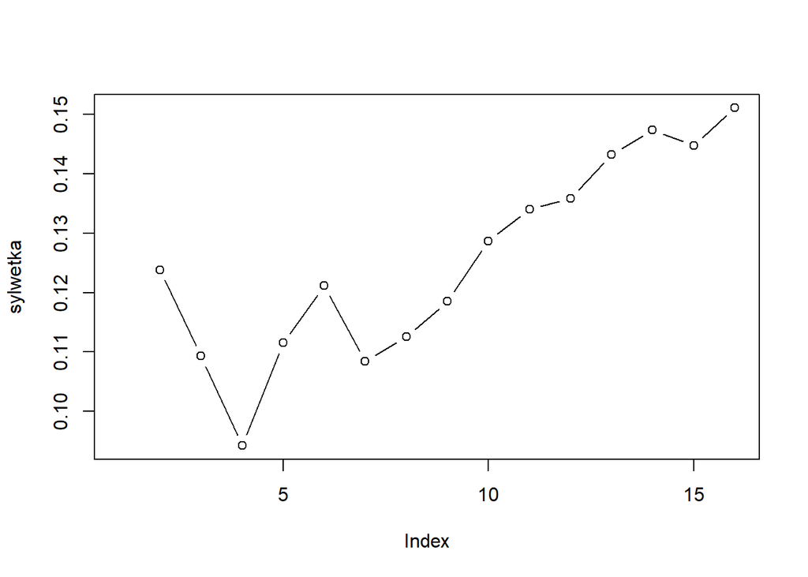

```r
plot(sylwetka,typ="b")
```

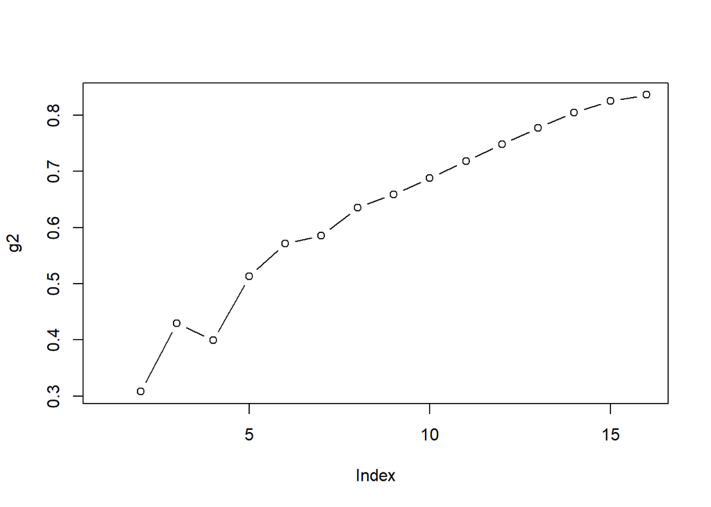

```r
plot(g2,typ="b")
```

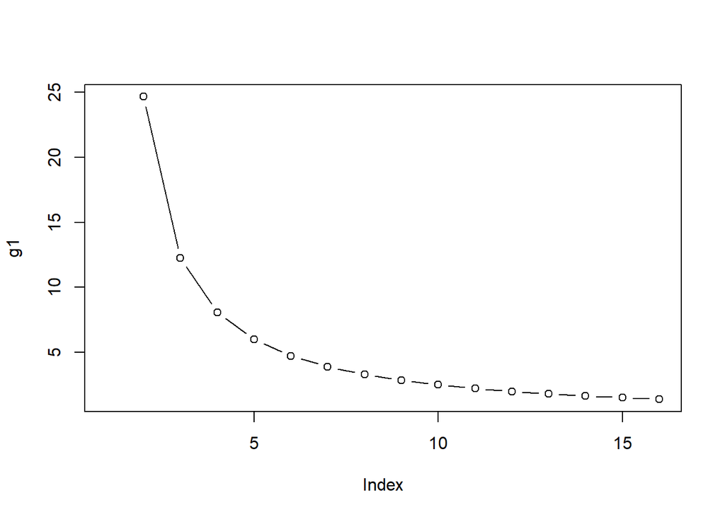

```r
plot(g1,typ="b")
```

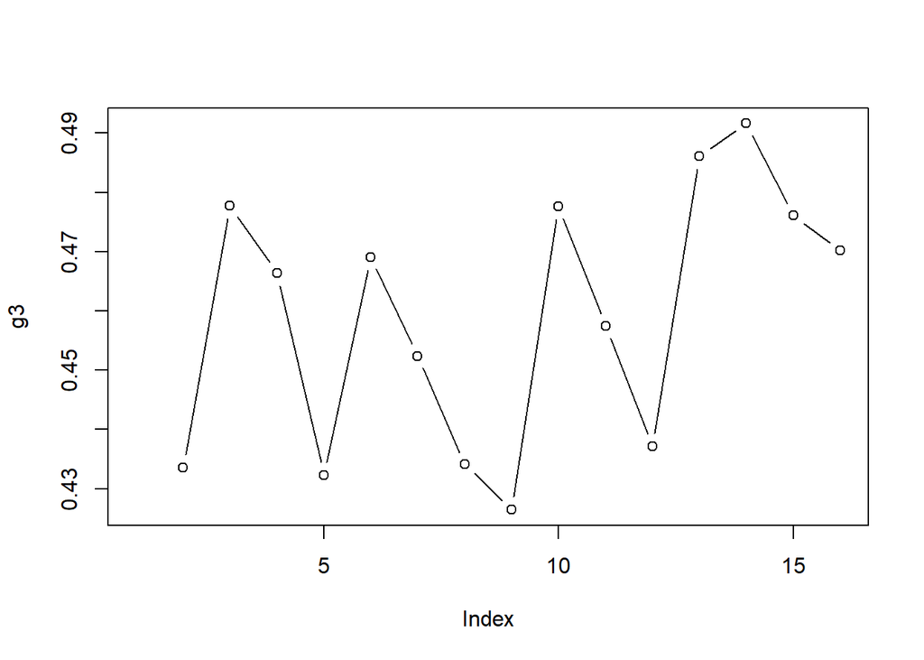

```r
plot(g3,typ="b")
```

Indeksy G1, G2 oraz Silhoutte szukają wartości jak najwyższej, gdy G3 - jak najniższej. Jak widać, uzyskane wyniki nie są jednoznaczne. Chciałbym uniknąć ilości skupień większej niż 10, o ile nie okaże się to konieczne. Indeksy sugerują kolejno:  
Sylwetkowy - 6, ew. 9, 10  
G1 - od około 6-7 spadki wydają się być stosunkowo płynne  
G2 - 6, 8, ew. więcej  
G3 - 5, 8, 9